# Effects of Loan attributes on Loan amount and Status

## by Marina Atef

## Investigation Overview

> This investigation explanetor a dataset containing 113,937 loans and their attributes and i'm most interested in what features are best for predicting Loan amount and Status

## Dataset Overview

> after cleaning dataset there are 58539 loans in the dataset with 13 features (Term ,LoanStatus ,BorrowerRate ,LenderYield ,ProsperScore,ListingCategory (numeric),EmploymentStatus,LoanOriginalAmount,EstimatedLoss,EstimatedReturn,IncomeVerifiable). Most variables are numeric in nature and the variables LoanStatus , Occupation and EmploymentStatus is object datatype but ProsperScore and Term are ordered variable with the following levels.  
> ProsperScore : 1 , 2 , 3 ... , 10  
> Term : 12 , 36 , 60

## distribution of Loan Status

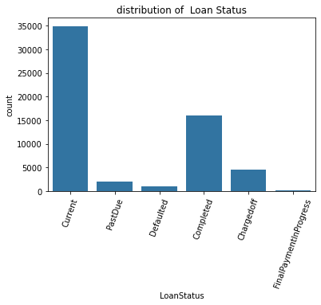

## distribution of Loan Original Amount

> most loans in a high range between 1000 and 20000 ,Plotted on a logarithmic scale.

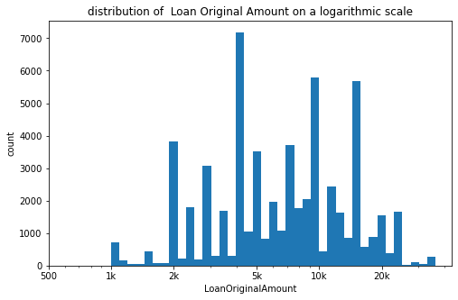

## distribution of Borrower Rate

> The Borrower's interest rate for the loan ,it takes values in small range

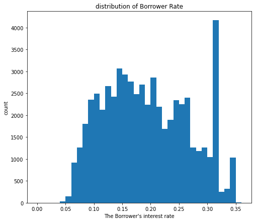

## distribution of Estimated Return

The estimated return assigned to the listing at the time it was created. Estimated return is the difference between the Estimated Effective Yield and the Estimated Loss Rate , most loans has Estimated Return in small range --> (0,0.2) but it is seems like normal distribution

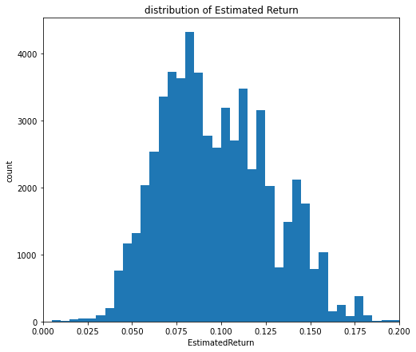

## Estimated Loss and Estimated Return against lender Yield and BrroweRate

> Estimated Loss and Estimated Return are highly correlated with lenderYield and BrroweRate

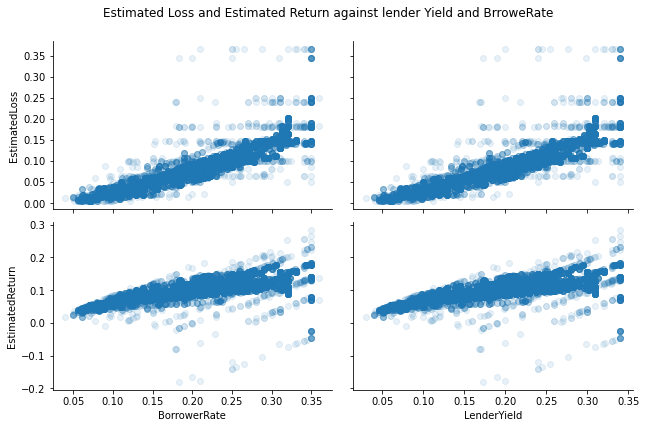

## Loan Status by Estimated Return and Borrower Rate

### it will help to predict Loan Status

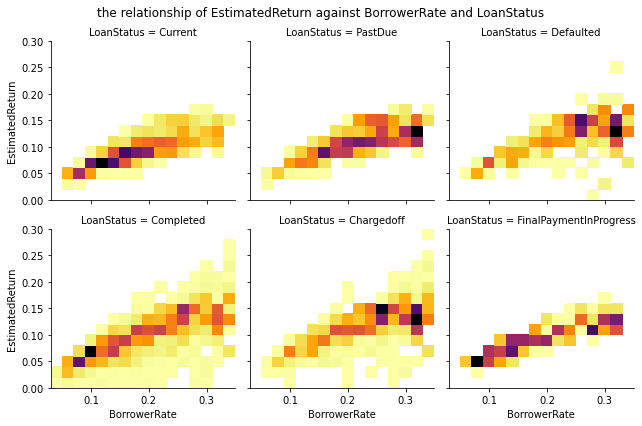